# R tutorial 4

Francisco A. Castro Rivera

2026-Oct-30. 07:03 PM

#Setup

```r
library(tidyverse)
library(readxl)
library(lessR)
library(BSDA)

df <- read_excel("butterflies_pesticides.xlsx")
head(df, 6)
```

```
## # A tibble: 6 × 2
##   Group  `Wing Length`
##   <chr>          <dbl>
## 1 group1          657.
## 2 group1          635.
## 3 group1          675.
## 4 group1          650.
## 5 group1          664.
## 6 group1          634.
```

```r
table(df$Group)
```

```
##
## group1 group2
##     40     40
```

# Q1: Normality test

```r
shapiro.test(df$`Wing Length`)
```

```
##
##  Shapiro-Wilk normality test
##
## data:  df$`Wing Length`
## W = 0.97134, p-value = 0.06913
```

```r
df |>
  group_by(Group) |>
  summarise(n = n(),
            mean = mean(`Wing Length`),
            sd = sd(`Wing Length`),
            shapiro_W = shapiro.test(`Wing Length`)$statistic,
            shapiro_p = shapiro.test(`Wing Length`)$p.value) |>
  head(6)
```

```
## # A tibble: 2 × 6
##   Group      n  mean    sd shapiro_W shapiro_p
##   <chr>  <int> <dbl> <dbl>     <dbl>     <dbl>
## 1 group1    40  632.  32.9     0.958     0.146
## 2 group2    40  593.  51.9     0.978     0.625
```

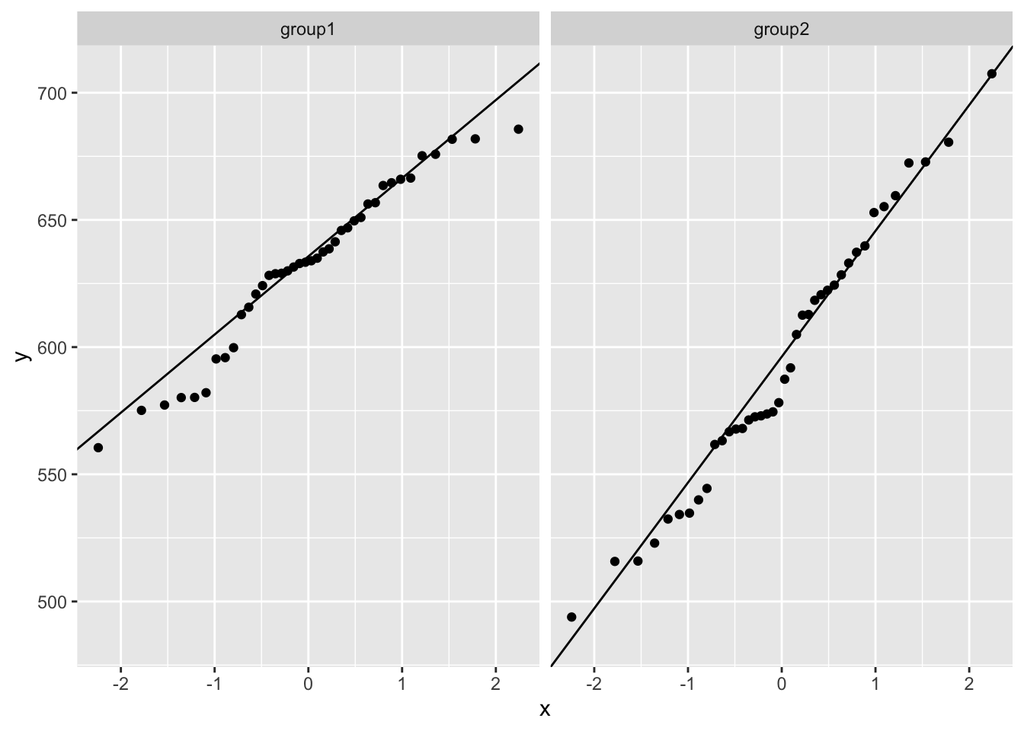

```r
ggplot(df, aes(sample = `Wing Length`)) +
  stat_qq() + stat_qq_line() +
  facet_wrap(~ Group)
```

# Q2: Equality of variances test

```r
var.test(`Wing Length` ~ Group, data = df)
```

```
##
##  F test to compare two variances
##
## data:  Wing Length by Group
## F = 0.40274, num df = 39, denom df = 39, p-value = 0.005512
## alternative hypothesis: true ratio of variances is not equal to 1
## 95 percent confidence interval:
##  0.2130078 0.7614644
## sample estimates:
## ratio of variances
##           0.402738
```

```r
bartlett.test(`Wing Length` ~ Group, data = df)
```

```
##
##  Bartlett test of homogeneity of variances
##
## data:  Wing Length by Group
## Bartlett's K-squared = 7.7023, df = 1, p-value = 0.005515
```

# Q3: Statistical test

```r
t.test(`Wing Length` ~ Group, data = df, var.equal = FALSE)
```

```
##
##  Welch Two Sample t-test
##
## data:  Wing Length by Group
## t = 3.9832, df = 66.029, p-value = 0.0001721
## alternative hypothesis: true difference in means between group group1 and group group2 is not equal to 0
## 95 percent confidence interval:
##  19.29467 58.07713
## sample estimates:
## mean in group group1 mean in group group2
##             632.1756             593.4897
```

```r
m <- df |> group_by(Group) |> summarise(mean = mean(`Wing Length`), sd = sd(`Wing Length`))
m |> head(6)
```

```
## # A tibble: 2 × 3
##   Group   mean    sd
##   <chr>  <dbl> <dbl>
## 1 group1  632.  32.9
## 2 group2  593.  51.9
```

```r
sp <- sqrt(mean(m$sd^2))
(m$mean[2] - m$mean[1]) / sp
```

```
## [1] -0.89066
```

# Q4: ggplot

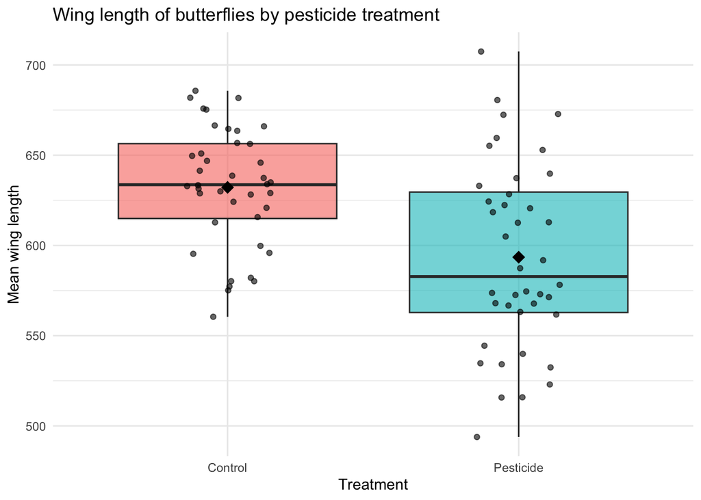

```r
ggplot(df, aes(x = Group, y = `Wing Length`, fill = Group)) +
  geom_boxplot(alpha = 0.6, outlier.shape = NA) +
  geom_jitter(width = 0.15, alpha = 0.6) +
  stat_summary(fun = mean, geom = "point", shape = 18, size = 4, color = "black") +
  scale_x_discrete(labels = c("group1" = "Control", "group2" = "Pesticide")) +
  labs(title = "Wing length of butterflies by pesticide treatment",
       x = "Treatment", y = "Mean wing length") +
  theme_minimal() +
  theme(legend.position = "none")
```

# Q5: Conclusions:

The objective of this study was to determine whether exposure to pesticides during the larval stage affects adult butterfly wing length. Mean wing length was measured in 80 butterflies, 40 treated with pesticides (group 2) and 40 untreated controls (group 1). Normality was assessed with Shapiro-Wilk tests and Q-Q plots, and both groups met the assumption (group 1: W = 0.958, p = 0.146; group 2: W = 0.978, p = 0.625). Equality of variances was assessed with an F test, which indicated unequal variances (F = 0.403, p = 0.0055), so a Welch two-sample t-test was used with α = 0.05. Pesticide-treated butterflies had significantly shorter wings (mean = 593.49 ± 51.9 SD) than controls (mean = 632.18 ± 32.9 SD); t(66.03) = 3.98, p = 0.00017, with a mean difference of 38.69 (95% CI: 19.29 to 58.08). The boxplot shows a lower median and a wider spread in the pesticide group. The difference is about 6% of the control mean, and Cohen’s d is about 0.89, a large effect. This suggests that larval pesticide exposure reduces adult wing size, which is likely biologically meaningful because shorter wings can impair flight, dispersal, foraging, and mate finding, and so could reduce fitness. The larger spread in the treated group also suggests that individuals vary in how strongly they respond to the pesticide. Because the data come from one experiment, the result shows an association under these conditions and should be confirmed with replication.